# ST661 R prog Assignment #3

Paul Williamson, 18145469 AND Ravinder Pal Singh, 18250396

16 November 2018

```r
#install.packages("tidyverse")
#install.packages("ggplot2")
#install.packages("reshape2")
#install.packages("ggthemes")
#install.packages("cowplot")
#install.packages("gridExtra")

library(ggplot2)
library(reshape2)
library(ggthemes)
library(scales)
library(tidyverse)
library(cowplot)
library(gridExtra)
```

## Question 1

*This code loads the data set Pima.tr, and its help file. Use ggplot2 for all plots.*

```r
library(MASS)
head(Pima.tr)
```

```
##   npreg glu bp skin  bmi   ped age type
## 1     5  86 68   28 30.2 0.364  24   No
## 2     7 195 70   33 25.1 0.163  55  Yes
## 3     5  77 82   41 35.8 0.156  35   No
## 4     0 165 76   43 47.9 0.259  26   No
## 5     0 107 60   25 26.4 0.133  23   No
## 6     5  97 76   27 35.6 0.378  52  Yes
```

```r
str(Pima.tr)
```

```
## 'data.frame':    200 obs. of  8 variables:
##  $ npreg: int  5 7 5 0 0 5 3 1 3 2 ...
##  $ glu  : int  86 195 77 165 107 97 83 193 142 128 ...
##  $ bp   : int  68 70 82 76 60 76 58 50 80 78 ...
##  $ skin : int  28 33 41 43 25 27 31 16 15 37 ...
##  $ bmi  : num  30.2 25.1 35.8 47.9 26.4 35.6 34.3 25.9 32.4 43.3 ...
##  $ ped  : num  0.364 0.163 0.156 0.259 0.133 ...
##  $ age  : int  24 55 35 26 23 52 25 24 63 31 ...
##  $ type : Factor w/ 2 levels "No","Yes": 1 2 1 1 1 2 1 1 1 2 ...
```

*Using this dataset:*

1. Make a scatterplot plot of bp versus npreg.

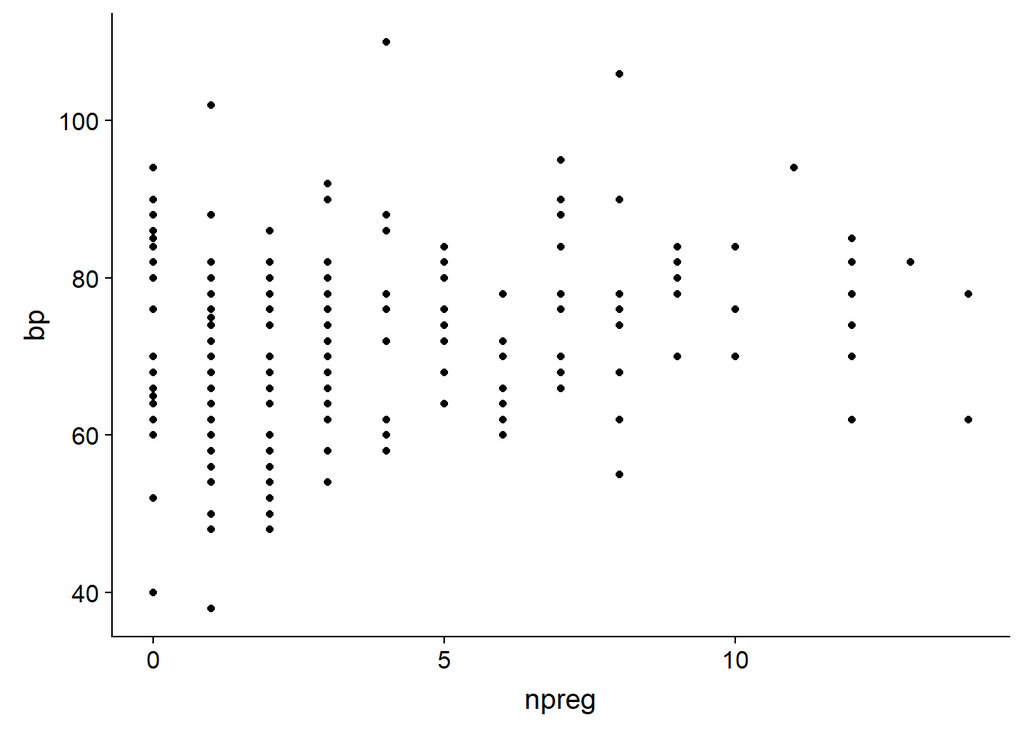

```r
plotty <- ggplot(Pima.tr,aes(npreg,bp))
plotty + geom_point()
```

2. Using the function cut_interval, construct a factor version of npreg with n=4 levels.
   - Call this new variable npregf.
   - Add this variable to dataset Pima.tr._

```r
head(Pima.tr)
```

```
##   npreg glu bp skin  bmi   ped age type
## 1     5  86 68   28 30.2 0.364  24   No
## 2     7 195 70   33 25.1 0.163  55  Yes
## 3     5  77 82   41 35.8 0.156  35   No
## 4     0 165 76   43 47.9 0.259  26   No
## 5     0 107 60   25 26.4 0.133  23   No
## 6     5  97 76   27 35.6 0.378  52  Yes
```

```r
Pima.tr$npregf <- as.factor(cut_interval(Pima.tr$npreg,4))
str(Pima.tr)
```

```
## 'data.frame':    200 obs. of  9 variables:
##  $ npreg : int  5 7 5 0 0 5 3 1 3 2 ...
##  $ glu   : int  86 195 77 165 107 97 83 193 142 128 ...
##  $ bp    : int  68 70 82 76 60 76 58 50 80 78 ...
##  $ skin  : int  28 33 41 43 25 27 31 16 15 37 ...
##  $ bmi   : num  30.2 25.1 35.8 47.9 26.4 35.6 34.3 25.9 32.4 43.3 ...
##  $ ped   : num  0.364 0.163 0.156 0.259 0.133 ...
##  $ age   : int  24 55 35 26 23 52 25 24 63 31 ...
##  $ type  : Factor w/ 2 levels "No","Yes": 1 2 1 1 1 2 1 1 1 2 ...
##  $ npregf: Factor w/ 4 levels "[0,3.5]","(3.5,7]",..: 2 2 2 1 1 2 1 1 1 1 ...
```

3. Plot boxplots of bp for each npregf level.

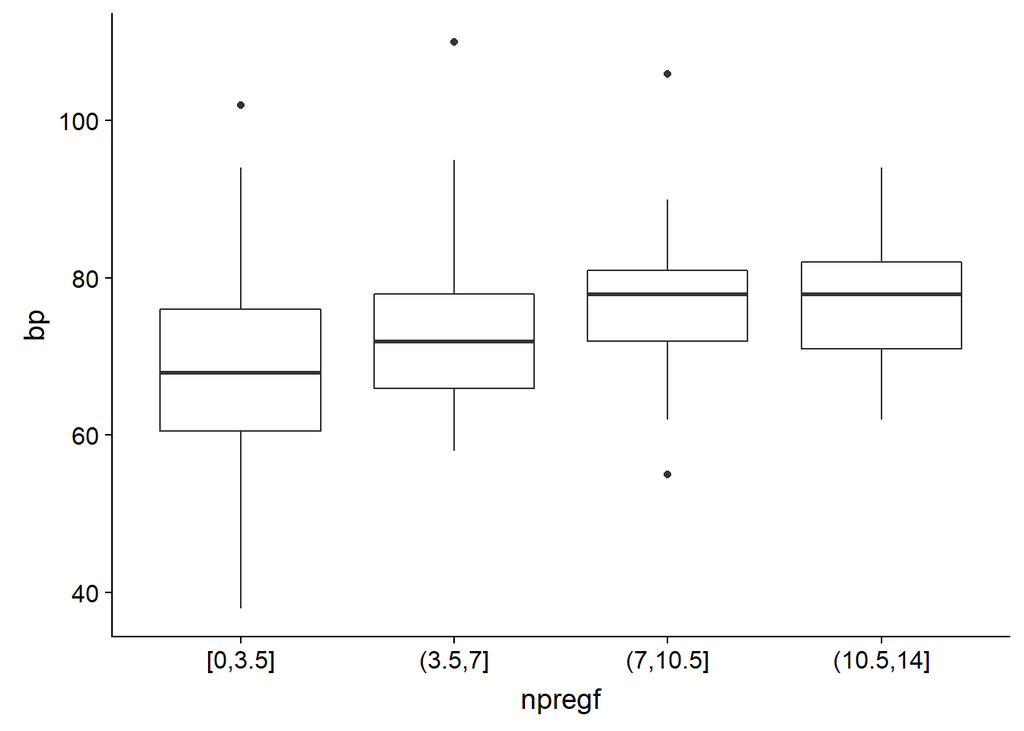

```r
plotty <- ggplot(Pima.tr,aes(npregf,bp))
plotty + geom_boxplot()
```

4. Make a scatterplot of glu versus age. Use colour to show variable type and add smooths for the two groups.

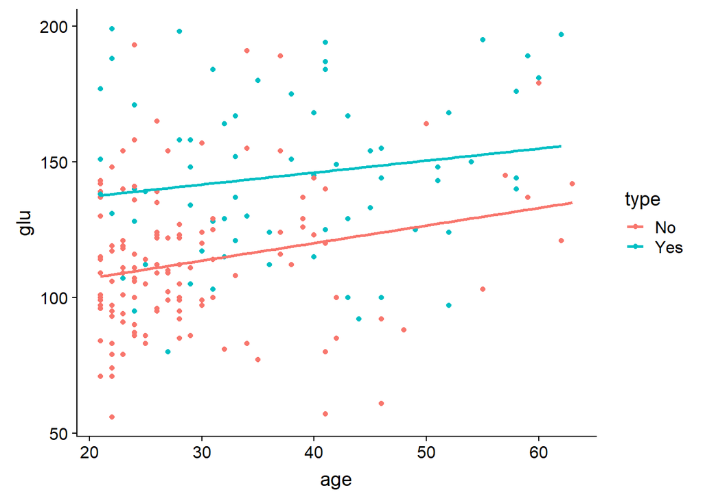

```r
plotty <- ggplot(Pima.tr,aes(age,glu, colour=type))
plotty + geom_point() + geom_smooth(se = FALSE, method = lm)
```

5. Redo the previous plot, separating out the two types. (Colour is not now needed)

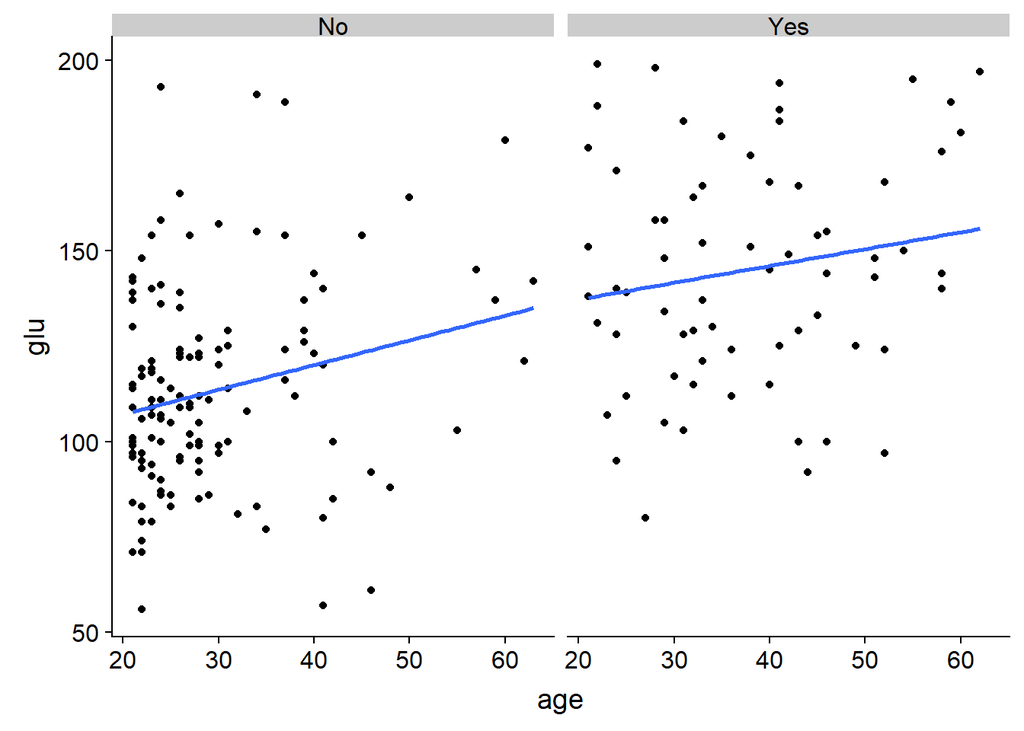

```r
plotty <- ggplot(Pima.tr,aes(age,glu))
plotty + geom_point() + geom_smooth(se = FALSE, method = lm) + facet_grid(~type)
```

## Question 2

```r
x2016 <- c(10,40,38,23,18,13,44)
x2017 <- c(4,33,28,22,22,16,33)
agegroup <- c("0-15","16-25","26-35","36-45","46-55","56-65","66+")
rs_data <- data.frame(x2016, x2017,agegroup)
# str(rs_data)# check data

formatted_rs_data <- melt(rs_data) # re-format the data to prepare for plotting
#str(formatted_rs_data) # check format of new dataframe
levels(formatted_rs_data$variable) <- c("2016", "2017") # rename levels in formatted data

#  create plot
plotty <- ggplot(formatted_rs_data, aes(x=agegroup, y=value, fill=variable, width=0.5))# call ggplot function
plotty <- plotty + geom_bar(stat='identity', position='dodge') # 'dodge' position bars side by side
plotty <- plotty + geom_text(aes(label=value),vjust = -1.3, position=position_dodge(0.5)) # adjust position of value labels
plotty <- plotty + scale_fill_manual(values=c("grey50", "olivedrab3"))# colour fill the bars
#plotty # ok up to here

# adjust y-axis elements
plotty <- plotty + scale_y_continuous(limits = c(0,50), breaks = seq(0,50,by=5), minor_breaks = seq(5,50,by=5))
#plotty # ok up to here

# adjust theme elements
plotty <- plotty + theme(panel.background = element_rect(fill = "white",colour = "white"))
plotty <- plotty + theme(panel.grid.major.y = element_line(colour = "grey", size = 0.5))
plotty <- plotty + theme(panel.grid.minor.y = element_line(colour = "grey", size = 0.5))
plotty <- plotty + theme(panel.grid.major.x = element_blank(), panel.grid.minor.x = element_blank())
plotty <- plotty + theme(axis.ticks.x = element_blank(), axis.ticks.y = element_blank())
plotty <- plotty + theme(axis.title.y=element_blank(), axis.title.x = element_blank())
plotty <- plotty + theme(plot.margin=unit(c(0.2,0.5,0.2,0.2),"cm"))
#plotty # ok up to here

# adjust more theme elements for the legend
plotty <- plotty + theme(legend.position="bottom")
plotty <- plotty + theme(legend.title=element_blank())
plotty <- plotty + theme(legend.key.size = unit(0.3,"cm"))
plotty <- plotty + theme(legend.text = element_text(margin = margin(r = 10, unit = "pt")))

# print grey border around whole lot
plotty <- plotty + theme(plot.background = element_rect(colour = 'grey'))
# print plot title above
#plotty <- plotty + ggtitle("Figure 8. Deaths by age group, January to December 31st 2017 vs 2016")
#plotty <- plotty + theme(plot.title = element_text(color="#000000", face="bold", size=11))
```

**Figure 8. Deaths by age group, January to December 31st 2017 vs 2016**

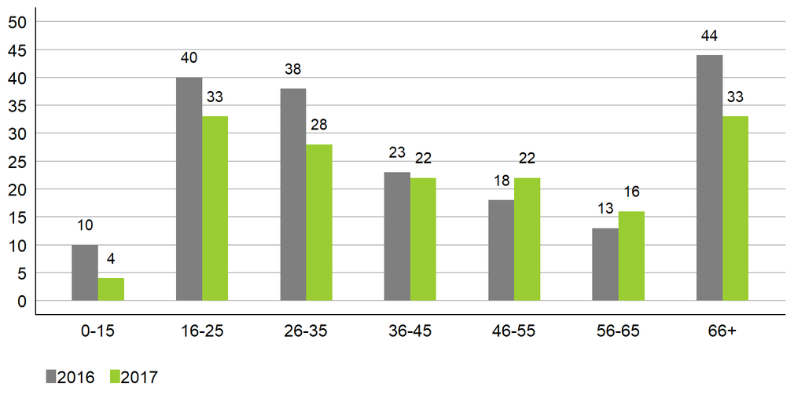

***

******

## Question 3

*The data Hep2012.csv contains data with the points athletes received from each event in the Heptathlon in the 2012 Olympics.*

*(a) Pose a question relating to the data.*

*How soon into the Heptathlon (7 events) is it possible to see a winning lead. Is it possible to discern any patterns in the scoring which might indicate which athletes are stronger in which events.*

*(b) Using ggplot, construct a visualisation which helps to answer this question.*

Steps:

```
+  Load data
+  Get Points total per athlete (rowSums, na.rm)
+  Sort data in ascending order (order)
+  Subset top 10 rows~bottom 10 scores & bottom 10 rows~top 10 scores (using [] notation)
+  Format data to prepare for plotting (gather)
+  Create two proportional barplots with indicating overall scores and proportions per athlete per event (ggplot)
+  Conclusion: Analyse most and least points scored by the athletes ()
```

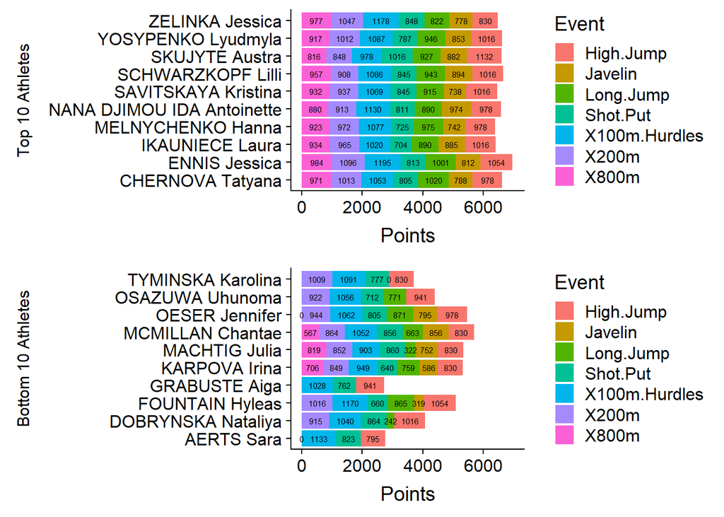

*(d) Explain why you selected this particular visualisation.*

*We chose this particular visualisation for a number of reasons. Firstly, it showed an interesting perspective on the overall accumulation of points as each individual event concluded. It is also possible to see the proportional effect of the points scored per event as they accumulated. Finally the form we chose to a certain extent also mimics the progress of the Heptathlon. This makes it easy to interpret for any audience.*